# MUSA Practicum Nighttime Economy

corr_type

Avg.Visits.AbsError

Avg.PercentError

1. Neighborhood Subcenter

35395.81

35.45713

2. Neighborhood Center

30001.03

27.34941

3. Community Center

23782.05

26.20506

4. Regional Center

55846.59

53.01493

5. Superregional Center

100226.49

44.81103

6. Speciality Center

28878.85

35.71694

Finally, the below figures split out errors by corridor type.

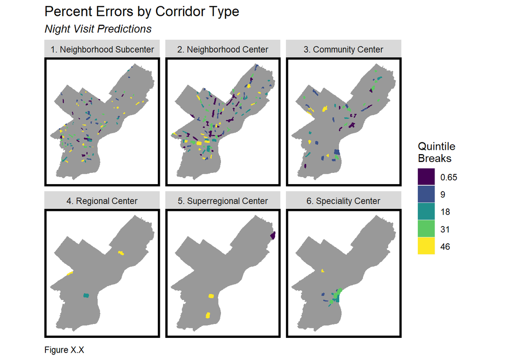

```r
map_preds %>%
  # left_join(., st_drop_geometry(phl_corridors_pred), by = "corridor") %>%
  # drop_na(corr_type) %>%
  st_as_sf() %>%
  ggplot() +
  geom_sf(data = phl_boundary, fill = 'grey60', color = "transparent") +
  geom_sf(aes(fill = q5(PercentError), color = q5(PercentError))) +
  scale_fill_manual(values = palette5,
                      labels=qBr(map_preds, "PercentError"),
                      name="Quintile\nBreaks") +
    scale_colour_manual(values = palette5,
                      labels=qBr(map_preds, "PercentError"),
                      name="Quintile\nBreaks") +
  labs(title="Percent Errors by Corridor Type",
       subtitle = "Night Visit Predictions",
       caption = "Figure X.X") +
  mapTheme() +
  facet_wrap(~corr_type)
```

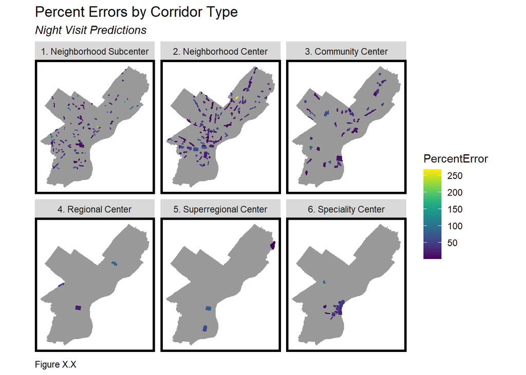

```r
map_preds %>%
  # left_join(., st_drop_geometry(phl_corridors_pred), by = "corridor") %>%
  # drop_na(corr_type) %>%
  st_as_sf() %>%
  ggplot() +
  geom_sf(data = phl_boundary, fill = 'grey60', color = "transparent") +
  geom_sf(aes(fill = PercentError, color = PercentError)) +
  scale_fill_viridis() +
  scale_color_viridis() +
  labs(title="Percent Errors by Corridor Type",
       subtitle = "Night Visit Predictions",
       caption = "Figure X.X") +
  mapTheme() +
  facet_wrap(~corr_type)
```

## Linear Model Removing Outliers

### Feature Summary

The following code removes the Market East corridor and any observations with over 500,000 night visits per square mile.

```r
dat_pred_agg_sub <- dat_pred_agg[dat_pred_agg$corridor!="Market East" &
                                 dat_pred_agg$Night_visits_sqmi<500000,]

set.seed(414)
inTrain.sub <- createDataPartition(y=dat_pred_agg_sub$Night_visits_sqmi_log, p = .60, list = FALSE)

phl.training.sub <- dat_pred_agg_sub[inTrain.sub,]
phl.test.sub <- dat_pred_agg_sub[-inTrain.sub,]

#Multivariate regression
reg1.sub <-
  lm(Night_visits_sqmi_log ~ ., #change lm to ranger, predictions are a little different
     data = st_drop_geometry(phl.training.sub) %>%
             dplyr::select(reg.vars))

summary(reg1.sub)
```

```
##
## Call:
## lm(formula = Night_visits_sqmi_log ~ ., data = st_drop_geometry(phl.training.sub) %>%
##     dplyr::select(reg.vars))
##
## Residuals:
##     Min      1Q  Median      3Q     Max
## -3.6200 -0.3150  0.0232  0.3767  2.1870
##
## Coefficients:
##                                    Estimate Std. Error t value Pr(>|t|)
## (Intercept)                       8.013e+00  5.174e-01  15.486  < 2e-16 ***
## phl_building_size_log             5.587e-02  1.634e-02   3.419 0.000642 ***
## phl_UPenn                         9.012e-06  2.116e-06   4.258 2.16e-05 ***
## sg_distance_home_log             -2.614e-01  3.728e-02  -7.012 3.28e-12 ***
## sg_dwell                          1.284e-03  2.820e-04   4.554 5.62e-06 ***
## count_bars_a_log                  1.482e-02  4.912e-02   0.302 0.762897
## count_rest_a_log                  4.683e-01  3.069e-02  15.259  < 2e-16 ***
## count_arts_a_log                  4.527e-02  5.923e-02   0.764 0.444734
## count_grocery_a_log               1.549e-01  3.019e-02   5.131 3.19e-07 ***
## count_sports_a                    3.616e-03  5.569e-04   6.492 1.08e-10 ***
## count_retailmix_top              -1.619e-02  3.766e-03  -4.300 1.79e-05 ***
## count_retailmix_sub_log           7.143e-01  4.421e-02  16.159  < 2e-16 ***
## count_openlate_log               -1.168e-01  3.386e-02  -3.450 0.000573 ***
## nn_transit_log                   -1.547e-01  2.356e-02  -6.567 6.65e-11 ***
## nn_parks_log                      1.147e-01  4.226e-02   2.715 0.006688 **
## nn_trolley                       -9.865e-06  3.026e-06  -3.260 0.001135 **
## count_late_tag                   -1.467e-03  3.957e-04  -3.708 0.000215 ***
## corr_type2. Neighborhood Center  -1.024e-01  3.934e-02  -2.603 0.009304 **
## corr_type3. Community Center     -6.177e-02  5.916e-02  -1.044 0.296599
## corr_type4. Regional Center       6.601e-01  1.511e-01   4.369 1.32e-05 ***
## corr_type5. Superregional Center  1.727e+00  1.917e-01   9.008  < 2e-16 ***
## corr_type6. Speciality Center     1.607e-01  7.623e-02   2.108 0.035202 *
## count_late_log                    1.967e-01  5.194e-02   3.788 0.000157 ***
## demo_pctWhite                    -2.018e-03  6.664e-04  -3.029 0.002489 **
## demo_medAge                       3.340e-03  2.234e-03   1.495 0.135027
## demo_popdens                      4.080e-06  1.941e-06   2.102 0.035713 *
## demo_medrent                      2.945e-04  7.278e-05   4.047 5.41e-05 ***
## demo_MHI                         -6.631e-06  1.065e-06  -6.225 5.96e-10 ***
## ---
## Signif. codes:  0 '***' 0.001 '**' 0.01 '*' 0.05 '.' 0.1 ' ' 1
##
## Residual standard error: 0.5775 on 1849 degrees of freedom
## Multiple R-squared:  0.5582, Adjusted R-squared:  0.5518
## F-statistic: 86.53 on 27 and 1849 DF,  p-value: < 2.2e-16
```

### Errors

Next we compare the errors in the model removing outliers to the baseline model. There is a small improvement with the outlier observations removed.

```r
#Error Table
phl.test.sub <-
  phl.test.sub %>%
  st_drop_geometry() %>%
  dplyr::mutate(Regression = "Linear Regression Removing Outliers",
         Visits.Predict = exp(predict(reg1.sub, phl.test.sub)),
         Visits.Error = Visits.Predict - Night_visits_sqmi,
         Visits.AbsError = abs(Visits.Predict - Night_visits_sqmi),
         Visits.APE = (abs(Visits.Predict - Night_visits_sqmi)) / Visits.Predict)

rbind(phl.test, phl.test.sub) %>%
  group_by(Regression) %>%
  dplyr::summarize(MAE = mean(Visits.AbsError, na.rm = T),
                   MAPE = mean(Visits.AbsError, na.rm = T) / mean(Night_visits_sqmi, na.rm = T)) %>%
  kable(caption = "MAE and MAPE for Test Set Data") %>% kable_styling()
```

MAE and MAPE for Test Set Data

| Regression | MAE | MAPE |
| --- | --- | --- |
| Baseline Regression | 40919.29 | 0.4013560 |
| Linear Regression Removing Outliers | 39429.05 | 0.3985702 |

The following scatterplots also indicate the data is more heterogenous than before, but in the subsset data, we are under-predicting more than in the full data model.

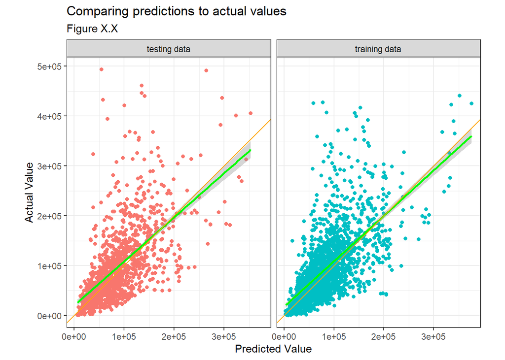

```r
#Error Scatterplot
reg1.sub_predict <- exp(predict(reg1.sub, newdata = phl.test.sub))

rmse.train <- caret::MAE(exp(predict(reg1.sub)), phl.training.sub$Night_visits_sqmi)
rmse.test <- caret::MAE(reg1.sub_predict, phl.test.sub$Night_visits_sqmi)

preds.train.sub <- data.frame(pred   = exp(predict(reg1.sub)),
                          actual = phl.training.sub$Night_visits_sqmi,
                          source = "training data")
preds.test.sub  <- data.frame(pred   = reg1.sub_predict,
                          actual = phl.test.sub$Night_visits_sqmi,
                          source = "testing data")

preds.sub <- rbind(preds.train.sub, preds.test.sub)

ggplot(preds.sub, aes(x = pred, y = actual, color = source)) +
  geom_point() +
  geom_smooth(method = "lm", color = "green") +
  geom_abline(color = "orange") +
  theme_bw() +
  coord_equal() +
  facet_wrap(~source, ncol = 2) +
  labs(title = "Comparing predictions to actual values",
       x = "Predicted Value",
       y = "Actual Value",
       subtitle = "Figure X.X") +
  theme(
    legend.position = "none"
  )
```

## Random Forest Model

#Feature Selection

```r
set.seed(414)
inTrain <- createDataPartition(y=dat_pred_agg$Night_visits_sqmi_log, p = .60, list = FALSE)

phl.training.rf <- dat_pred_agg[inTrain,]
phl.test.rf <- dat_pred_agg[-inTrain,]

#Multivariate regression
rf1 <-
  ranger(Night_visits_sqmi_log ~ ., #change lm to ranger, predictions are a little different
     data = st_drop_geometry(phl.training.rf) %>%
             dplyr::select(reg.vars),
     importance = "impurity")

rf1
```

```
## Ranger result
##
## Call:
##  ranger(Night_visits_sqmi_log ~ ., data = st_drop_geometry(phl.training.rf) %>%      dplyr::select(reg.vars), importance = "impurity")
##
## Type:                             Regression
## Number of trees:                  500
## Sample size:                      1896
## Number of independent variables:  23
## Mtry:                             4
## Target node size:                 5
## Variable importance mode:         impurity
## Splitrule:                        variance
## OOB prediction error (MSE):       0.2200401
## R squared (OOB):                  0.7069685
```

The below Figure shows the importance of the various features in the model, with the density of restauratns, the businesses open late, the distance from home and the population density being the most important features.

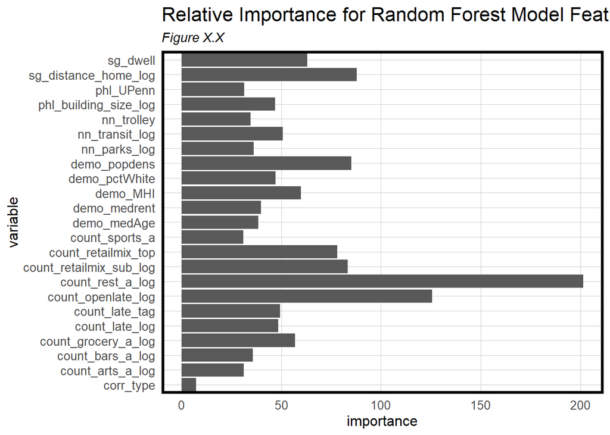

```r
#Importance bar plot
rf1_importance <-
  importance(rf1) %>%
  as.data.frame() %>%
  setNames(c("importance")) %>%
  rownames_to_column(., "variable") %>%
  as.data.frame() %>%
  mutate(importance = as.vector(importance))

# rf1_importance <- rf1_importance[order(rf1_importance$importance, decreasing = TRUE),]
# rf1_importance$importance <- factor(rf1_importance$importance, levels = rf1_importance$importance)

rf1_importance %>%
  ggplot(aes(x=variable, y=importance)) +
  geom_col() +
  plotTheme() +
  labs(title = "Relative Importance for Random Forest Model Features",
       subtitle = "Figure X.X") +
  coord_flip()
```

### Error Terms

The below plots indicate that the errors are far more heteroschedastic than the previous models, but there seems to be a larger gap between the predicted and actual values as indicated by the orange and green lines. Suggestions on how to better align these?

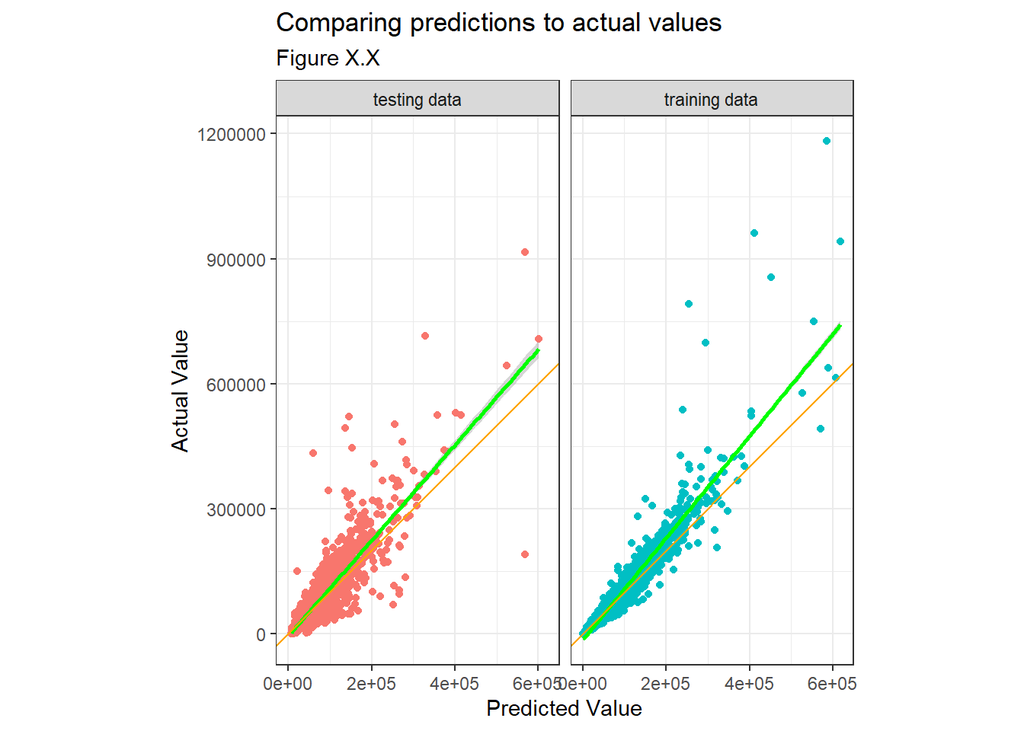

```r
#######
#Scatterplot
rf1_predict.train <- predict(rf1, data = st_drop_geometry(phl.training.rf))
rf1_predict.train <- exp(rf1_predict.train$predictions)

rf1_predict.test <- predict(rf1, data = st_drop_geometry(phl.test.rf))
rf1_predict.test <- exp(rf1_predict.test$predictions)

rmse.train.rf <- caret::MAE(rf1_predict.train, phl.training.rf$Night_visits_sqmi)
rmse.test.rf <- caret::MAE(rf1_predict.test, phl.test.rf$Night_visits_sqmi)

preds.train.rf <- data.frame(pred   = rf1_predict.train,
                          actual = phl.training.rf$Night_visits_sqmi,
                          source = "training data")
preds.test.rf  <- data.frame(pred   = rf1_predict.test,
                          actual = phl.test.rf$Night_visits_sqmi,
                          source = "testing data")

preds.rf <- rbind(preds.train.rf, preds.test.rf)

ggplot(preds.rf, aes(x = pred, y = actual, color = source)) +
  geom_point() +
  geom_smooth(method = "lm", color = "green") +
  geom_abline(color = "orange") +
  theme_bw() +
  coord_equal() +
  facet_wrap(~source, ncol = 2) +
  labs(title = "Comparing predictions to actual values",
       x = "Predicted Value",
       y = "Actual Value",
       subtitle = "Figure X.X") +
  theme(
    legend.position = "none"
  )
```

The below table compares the error terms of the random forest model to the previous two models, we see a noticeable improvement.

```r
#Error Table
phl.test.rf <-
  phl.test.rf %>%
  st_drop_geometry() %>%
  mutate(Regression = "Random Forest Regression",
         # Visits.Predict = exp(predict(reg1.sub, phl.test.sub)),
          Visits.Predict = rf1_predict.test,
         Visits.Error = Visits.Predict - Night_visits_sqmi,
         Visits.AbsError = abs(Visits.Predict - Night_visits_sqmi),
         Visits.APE = (abs(Visits.Predict - Night_visits_sqmi)) / Visits.Predict)

rbind(phl.test, phl.test.sub, phl.test.rf) %>%
  group_by(Regression) %>%
  dplyr::summarize(MAE = mean(Visits.AbsError, na.rm = T),
                   MAPE = mean(Visits.AbsError, na.rm = T) / mean(Night_visits_sqmi, na.rm = T)) %>%
  kable(caption = "MAE and MAPE for Test Set Data") %>% kable_styling()
```

MAE and MAPE for Test Set Data

| Regression | MAE | MAPE |
| --- | --- | --- |
| Baseline Regression | 40919.29 | 0.4013560 |
| Linear Regression Removing Outliers | 39429.05 | 0.3985702 |
| Random Forest Regression | 28183.13 | 0.2764337 |

### Cross Validation

We also see improvement in the error terms in the below histogram comparing the mean average error in the linear model to the random forest model.

```r
fitControl <- trainControl(method = "cv",
                           number = 10,
                           savePredictions = TRUE)
set.seed(414)


reg1.cv.rf <-
  train(Night_visits_sqmi_log ~ ., data = st_drop_geometry(dat_pred_agg) %>%
          dplyr::select(reg.vars),
        method = "ranger",
        trControl = fitControl,
        na.action = na.pass)

reg1.cv.rf.resample <- reg1.cv.rf$resample

reg1.cv.rf
```

```
## Random Forest
##
## 3159 samples
##   23 predictor
##
## No pre-processing
## Resampling: Cross-Validated (10 fold)
## Summary of sample sizes: 2843, 2843, 2843, 2843, 2843, 2843, ...
## Resampling results across tuning parameters:
##
##   mtry  splitrule   RMSE       Rsquared   MAE
##    2    variance    0.4653635  0.7264092  0.3183629
##    2    extratrees  0.4912662  0.7024039  0.3362564
##   14    variance    0.4441350  0.7447999  0.3067438
##   14    extratrees  0.4476023  0.7416718  0.3082499
##   27    variance    0.4490768  0.7383064  0.3103576
##   27    extratrees  0.4430299  0.7459121  0.3065532
##
## Tuning parameter 'min.node.size' was held constant at a value of 5
## RMSE was used to select the optimal model using the smallest value.
## The final values used for the model were mtry = 27, splitrule = extratrees
##  and min.node.size = 5.
```

[figure not shown]

```r
# ggplot(reg1.cv.rf.resample, aes(x=MAE)) +
#   geom_histogram(color = "grey40", fill = "#27fdf5", bins = 50) +
#   labs(title="Full Dataset: Histogram of Mean Average Error Across 100 Folds",
#        subtitle = "Figure X.X") +
#   plotTheme()

#Comparing random forest model and linear model errors.
rbind(reg1.cv.resample %>% mutate(Regression = "Linear Model"),
        reg1.cv.rf.resample %>% mutate(Regression = "Random Forest Model")) %>%
  ggplot(aes(x=MAE)) +
  geom_histogram(color = "grey40", fill = "#27fdf5", bins = 50) +
  labs(title="Full Dataset: Histogram of Mean Average Error Across 100 Folds",
       subtitle = "Figure X.X") +
  facet_wrap(~Regression, ncol = 1) +
  plotTheme()
```

### LOGO-CV

```r
dat_pred_cv <-
  dat_pred_agg %>%
  dplyr::select(date_range_start, Night_visits, Night_visits_sqmi, phl_area_sqmi, reg.vars) %>%
  dplyr::mutate(uniqueID = rownames(.),
                cvID = sample(round(nrow(dat_pred_agg) / 24), size=nrow(dat_pred_agg), replace = TRUE))

colnames(dat_pred_agg)
```

```
##  [1] "corridor"                "date_range_start"
##  [3] "corr_type"               "Night_visits"
##  [5] "Workday_visits"          "phl_area_sqmi"
##  [7] "Night_visits_sqmi"       "Night_visits_sqmi_log"
##  [9] "Workday_visits_sqmi"     "Workday_visits_sqmi_log"
## [11] "total"                   "phl_building_size"
## [13] "phl_building_size_log"   "phl_building_size_med"
## [15] "phl_UPenn"               "phl_rest_sqft"
## [17] "phl_rest_sqft_log"       "phl_bar_sqft"
## [19] "phl_bar_sqft_log"        "sg_dwell"
## [21] "sg_distance_home"        "sg_distance_home_log"
## [23] "count_bars_a"            "count_rest_a"
## [25] "count_arts_a"            "count_sports_a"
## [27] "count_hotels_a"          "count_grocery_a"
## [29] "count_retailmix_top"     "count_retailmix_sub"
## [31] "count_late_tag"          "count_openlate"
## [33] "count_bars_a_log"        "count_rest_a_log"
## [35] "count_arts_a_log"        "count_grocery_a_log"
## [37] "count_late_log"          "count_retailmix_top_log"
## [39] "count_retailmix_sub_log" "count_openlate_log"
## [41] "nn_transit"              "nn_parks"
## [43] "nn_busstop"              "nn_trolley"
## [45] "nn_parks_log"            "nn_transit_log"
## [47] "nn_busstop_log"          "nn_trolley_log"
## [49] "demo_popdens"            "demo_popdens_log"
## [51] "demo_pctWhite"           "demo_pctBlack"
## [53] "demo_pctHisp"            "demo_medAge"
## [55] "demo_MHI"                "demo_medrent"
## [57] "demo_pctHisp_log"        "geometry"
```

```r
crossValidate <- function(dataset, id, dependentVariable, indVariables) {

  allPredictions <- data.frame()
  cvID_list <- unique(dataset[[id]])

  for (i in cvID_list) {

    thisFold <- i
    cat("This hold out fold is", thisFold, "\n")

    fold.train <- filter(dataset, dataset[[id]] != thisFold) %>% as.data.frame() %>%
      dplyr::select(id, geometry, indVariables, dependentVariable)
    fold.test  <- filter(dataset, dataset[[id]] == thisFold) %>% as.data.frame() %>%
      dplyr::select(id, geometry, indVariables, dependentVariable)

    regression <-
      glm(Night_visits_sqmi_log ~ ., family = "poisson",
          data = fold.train %>%
            dplyr::select(-geometry, -id))

    thisPrediction <-
      mutate(fold.test, Prediction = predict(regression, fold.test, type = "response"))

    allPredictions <-
      rbind(allPredictions, thisPrediction)

  }
  return(st_sf(allPredictions))
}

# reg.rf.cv <-
#   crossValidate(
#   dataset = dat_pred_cv,
#   id = "cvID",
#   dependentVariable = "Night_visits_sqmi_log",
#   indVariables = reg.vars) %>%
#     dplyr::select(cvID = cvID, Night_visits_sqmi_log, Prediction, geometry)

reg.rf.date.CV <-
  crossValidate(
    dataset = dat_pred_cv,
    id = "date_range_start",
    dependentVariable = "Night_visits_sqmi_log",
    indVariables = reg.vars)
```

```
## This hold out fold is 2018-01-01T05:00:00Z
## This hold out fold is 2018-02-01T05:00:00Z
## This hold out fold is 2018-03-01T05:00:00Z
## This hold out fold is 2018-04-01T04:00:00Z
## This hold out fold is 2018-05-01T04:00:00Z
## This hold out fold is 2018-06-01T04:00:00Z
## This hold out fold is 2018-07-01T04:00:00Z
## This hold out fold is 2018-08-01T04:00:00Z
## This hold out fold is 2018-09-01T04:00:00Z
## This hold out fold is 2018-10-01T04:00:00Z
## This hold out fold is 2018-11-01T04:00:00Z
## This hold out fold is 2018-12-01T05:00:00Z
```

```r
reg.rf.date.CV <-
  cbind(reg.rf.date.CV, dat_pred_cv %>% dplyr::select(Night_visits, Night_visits_sqmi, phl_area_sqmi)) %>%
  dplyr::select(date_range_start,
                Night_visits_sqmi,
                Night_visits_sqmi_log,
                Night_visits,
                phl_area_sqmi,
                Prediction,
                geometry) %>%
  dplyr::mutate(Prediction = exp(Prediction),
                Prediction = Prediction * phl_area_sqmi,
                Error = Prediction - Night_visits,
                Abs.Error = abs(Error),
                MAPE = abs(Night_visits - Prediction) / Night_visits)

reg.rf.date.CV %>%
  st_drop_geometry() %>%
  dplyr::mutate(Month = date_range_start) %>%
  group_by(Month) %>%
  summarize(MAE = mean(Abs.Error, na.rm = TRUE),
            MAPE = mean(MAPE, na.rm = TRUE)) %>%
  kable() %>%
  kable_styling("striped", full_width = F)
```

| Month | MAE | MAPE |
| --- | --- | --- |
| 2018-01-01T05:00:00Z | 6135.629 | 1.1830686 |
| 2018-02-01T05:00:00Z | 2587.590 | 0.9044869 |
| 2018-03-01T05:00:00Z | 3871.458 | 2.1972005 |
| 2018-04-01T04:00:00Z | 3640.140 | 0.9916395 |
| 2018-05-01T04:00:00Z | 8734.102 | 2.2047105 |
| 2018-06-01T04:00:00Z | 3261.584 | 2.2581229 |
| 2018-07-01T04:00:00Z | 2615.236 | 1.4794954 |
| 2018-08-01T04:00:00Z | 6874.993 | 2.1305891 |
| 2018-09-01T04:00:00Z | 5912.447 | 2.8594588 |
| 2018-10-01T04:00:00Z | 3864.618 | 1.6577454 |
| 2018-11-01T04:00:00Z | 3922.045 | 1.2945791 |
| 2018-12-01T05:00:00Z | 1835.216 | 2.1954662 |

## Random Forest Model Removing Outliers

### Feature Summary

We know that the random forest model predicted on the full dataset fare more accurately than the linear model. How will it perform on the data subset we prepared above? The following code runs the random forest model on that subset.

```r
# dat_pred_agg %>%
#   filter(Night_visits_sqmi > 750000) %>%
#   select(corridor) %>%
#   ggplot()+
#   geom_sf(data=phl_boundary) +
#   geom_sf(fill = "red", color = "red") +
#   mapTheme()
#
# dat_pred_agg_sub_rf <-
#   dat_pred_agg %>%
#   filter(Night_visits_sqmi < 600000)

#Random forest with subset
set.seed(414)
inTrain <- createDataPartition(y=dat_pred_agg_sub$Night_visits_sqmi_log, p = .60, list = FALSE)

phl.training.rf.sub <- dat_pred_agg_sub[inTrain,]
phl.test.rf.sub <- dat_pred_agg_sub[-inTrain,]

#Multivariate regression
rf1.sub <-
  ranger(Night_visits_sqmi_log ~ ., #change lm to ranger, predictions are a little different
     data = st_drop_geometry(phl.training.rf.sub) %>%
             select(reg.vars),
     importance = "impurity")

rf1.sub
```

```
## Ranger result
##
## Call:
##  ranger(Night_visits_sqmi_log ~ ., data = st_drop_geometry(phl.training.rf.sub) %>%      select(reg.vars), importance = "impurity")
##
## Type:                             Regression
## Number of trees:                  500
## Sample size:                      1877
## Number of independent variables:  23
## Mtry:                             4
## Target node size:                 5
## Variable importance mode:         impurity
## Splitrule:                        variance
## OOB prediction error (MSE):       0.2167197
## R squared (OOB):                  0.7087357
```

### Errors

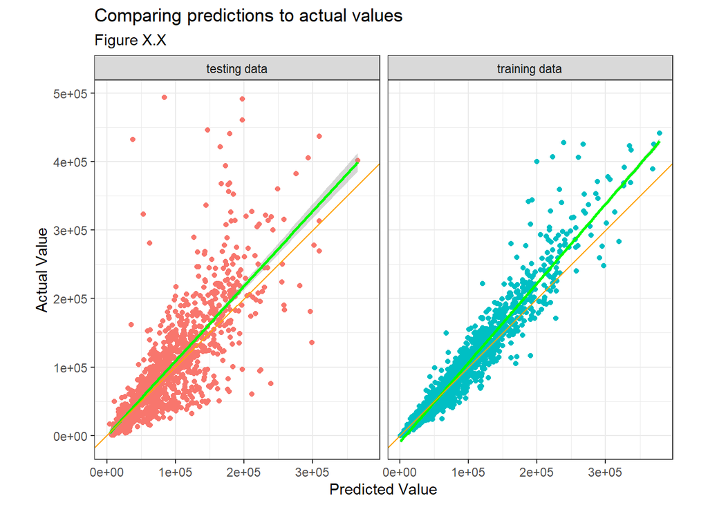

```r
#Scatterplot
rf1_predict.train.sub <- predict(rf1.sub, data = st_drop_geometry(phl.training.rf.sub))
rf1_predict.train.sub <- exp(rf1_predict.train.sub$predictions)

rf1_predict.test.sub <- predict(rf1.sub, data = st_drop_geometry(phl.test.rf.sub))
rf1_predict.test.sub <- exp(rf1_predict.test.sub$predictions)

rmse.train.rf.sub <- caret::MAE(rf1_predict.train.sub, phl.training.rf.sub$Night_visits_sqmi)
rmse.test.rf.sub <- caret::MAE(rf1_predict.test.sub, phl.test.rf.sub$Night_visits_sqmi)

preds.train.rf.sub <- data.frame(pred   = rf1_predict.train.sub,
                          actual = phl.training.rf.sub$Night_visits_sqmi,
                          source = "training data")
preds.test.rf.sub  <- data.frame(pred   = rf1_predict.test.sub,
                          actual = phl.test.rf.sub$Night_visits_sqmi,
                          source = "testing data")

preds.rf.sub <- rbind(preds.train.rf.sub, preds.test.rf.sub)

ggplot(preds.rf.sub, aes(x = pred, y = actual, color = source)) +
  geom_point() +
  geom_smooth(method = "lm", color = "green") + #Is the lm here right?
  geom_abline(color = "orange") +
  theme_bw() +
  coord_equal() +
  facet_wrap(~source, ncol = 2) +
  labs(title = "Comparing predictions to actual values",
       x = "Predicted Value",
       y = "Actual Value",
       subtitle = "Figure X.X") +
  theme(
    legend.position = "none"
  )
```

Comparing the error terms to the other models, we see that the subsetted random forest model actually performs slightly worse than the random forest model on the full set.

```r
#Error Table
phl.test.rf.sub <-
  phl.test.rf.sub %>%
  st_drop_geometry() %>%
  mutate(Regression = "Subset RF Regression",
         # Visits.Predict = exp(predict(reg1.sub, phl.test.sub)),
          Visits.Predict = rf1_predict.test.sub,
         Visits.Error = Visits.Predict - Night_visits_sqmi,
         Visits.AbsError = abs(Visits.Predict - Night_visits_sqmi),
         Visits.APE = (abs(Visits.Predict - Night_visits_sqmi)) / Visits.Predict)

rbind(phl.test, phl.test.sub, phl.test.rf, phl.test.rf.sub) %>%
  group_by(Regression) %>%
  dplyr::summarize(MAE = mean(Visits.AbsError, na.rm = T),
                   MAPE = mean(Visits.AbsError, na.rm = T) / mean(Night_visits_sqmi, na.rm = T)) %>%
  kable(caption = "MAE and MAPE for Test Set Data") %>% kable_styling()
```

MAE and MAPE for Test Set Data

| Regression | MAE | MAPE |
| --- | --- | --- |
| Baseline Regression | 40919.29 | 0.4013560 |
| Linear Regression Removing Outliers | 39429.05 | 0.3985702 |
| Random Forest Regression | 28183.13 | 0.2764337 |
| Subset RF Regression | 28758.30 | 0.2907044 |

### Workday Model

```r
##Linear Workday Model
set.seed(414)
inTrain.day <- createDataPartition(y=dat_pred_agg$Workday_visits_sqmi_log, p = .60, list = FALSE)

phl.training.day <- dat_pred_agg[inTrain.day,]
phl.test.day <- dat_pred_agg[-inTrain.day,]

reg.vars.day <- c('Workday_visits_sqmi_log',
              'phl_building_size_log',
              'phl_UPenn',
              # 'phl_Temple',
              # 'phl_CityHall',
              # 'phl_CityHall_log',
              # 'phl_rest_sqft_log',
              # 'phl_bar_sqft_log',
              # 'phl_vacrate_log',
              # 'phl_CenterCity',
              'sg_distance_home_log',
              'sg_dwell',
              'count_bars_a_log',
              'count_rest_a_log',
              'count_arts_a_log',
              'count_grocery_a_log',
              # 'count_childcare_a_log',
              # 'count_religious_a_log',
              # 'count_bars_a',
              # 'count_rest_a',
              # 'count_arts_a',
              # 'count_college_a',
              'count_sports_a',
              'count_retailmix_top',
              'count_retailmix_sub_log',
              'count_openlate_log',
              # 'count_museums_a',
              # 'count_amuse_a_log',
              # 'count_hotels_a',
              'nn_transit_log',
              # 'nn_parking',
              'nn_parks_log',
              # 'nn_busstop',
              'nn_trolley',
              'count_late_tag',
              # 'count_barpub_tag',
              'corr_type',
              'count_late_log',
              # 'count_barpub_log',
              'demo_pctWhite',
              # 'demo_pctBlack',
              # 'demo_pctHisp_log',
              'demo_medAge',
              'demo_popdens',
              # 'demo_popdens_log',
              'demo_medrent',
              'demo_MHI')

#Multivariate regression
reg1.day <-
  lm(Workday_visits_sqmi_log ~ .,
     data = st_drop_geometry(phl.training.day) %>%
       select(reg.vars.day))

#Random Forest Workday model
set.seed(414)
phl.training.rf.day <- dat_pred_agg[inTrain,]
phl.test.rf.day <- dat_pred_agg[-inTrain,]

#Multivariate regression
rf1.day <-
  ranger(Workday_visits_sqmi_log ~ ., #change lm to ranger, predictions are a little different
     data = st_drop_geometry(phl.training.rf.day) %>%
             select(reg.vars.day),
     importance = "impurity")

rf1_predict.train.day <- predict(rf1.day, data = st_drop_geometry(phl.training.rf.day))
rf1_predict.train.day <- exp(rf1_predict.train.day$predictions)

rf1_predict.test.day <- predict(rf1.day, data = st_drop_geometry(phl.test.rf.day))
rf1_predict.test.day <- exp(rf1_predict.test.day$predictions)

#Error table
phl.test.day <-
  phl.test.day %>%
  st_drop_geometry() %>%
  mutate(Regression = "Workday Linear Regression",
         Visits.Predict = exp(predict(reg1.day, phl.test.day)),
         Visits.Error = Visits.Predict - Workday_visits_sqmi,
         Visits.AbsError = abs(Visits.Predict - Workday_visits_sqmi),
         Visits.APE = (abs(Visits.Predict - Workday_visits_sqmi)) / Visits.Predict)

phl.test.rf.day <-
  phl.test.rf.day %>%
  st_drop_geometry() %>%
  mutate(Regression = "Workday Random Forest Regression",
         # Visits.Predict = exp(predict(rf1.day, phl.test.rf.day)),
         Visits.Predict = rf1_predict.test.day,
         Visits.Error = Visits.Predict - Workday_visits_sqmi,
         Visits.AbsError = abs(Visits.Predict - Workday_visits_sqmi),
         Visits.APE = (abs(Visits.Predict - Workday_visits_sqmi)) / Visits.Predict)

rbind(phl.test, phl.test.sub, phl.test.rf.sub, phl.test.rf, phl.test.day, phl.test.rf.day) %>%
  group_by(Regression) %>%
  dplyr::summarize(MAE = mean(Visits.AbsError, na.rm = T),
                   MAPE = mean(Visits.AbsError, na.rm = T) / mean(Night_visits_sqmi, na.rm = T)) %>%
  kable(caption = "MAE and MAPE for Test Set Data") %>% kable_styling()
```

MAE and MAPE for Test Set Data

| Regression | MAE | MAPE |
| --- | --- | --- |
| Baseline Regression | 40919.29 | 0.4013560 |
| Linear Regression Removing Outliers | 39429.05 | 0.3985702 |
| Random Forest Regression | 28183.13 | 0.2764337 |
| Subset RF Regression | 28758.30 | 0.2907044 |
| Workday Linear Regression | 108364.21 | 1.0688033 |
| Workday Random Forest Regression | 76013.62 | 0.7181341 |

### Tuning Hyperparameters

```r
#Package installs -------------------------------------------------------------
load.fun <- function(x) {
  x <- as.character(x)
  if(isTRUE(x %in% .packages(all.available=TRUE))) {
    eval(parse(text=paste("require(", x, ")", sep="")))
    print(paste(c(x, " : already installed; requiring"), collapse=''))
  } else {
    #update.packages()
    print(paste(c(x, " : not installed; installing"), collapse=''))
    eval(parse(text=paste("install.packages('", x, "')", sep="")))
    print(paste(c(x, " : installed and requiring"), collapse=''))
    eval(parse(text=paste("require(", x, ")", sep="")))
  }
}

########### Required Packages ###########
packages = c("bayesplot", "lme4", "rstan", "shinystan", "RcppEigen",
             "tidyverse", "tidyr", "AmesHousing", "broom", "caret", "dials", "doParallel", "e1071", "earth",
             "ggrepel", "glmnet", "ipred", "klaR", "kknn", "pROC", "rpart", "randomForest",
             "sessioninfo", "tidymodels","ranger", "recipes", "workflows", "themis","xgboost",
             "sf", "nngeo", "mapview")

for(i in seq_along(packages)){
  packge <- as.character(packages[i])
  load.fun(packge)
}
```

[output not shown]

[output cut: 17 more lines]

```r
set.seed(414)
data_split <- initial_split(dat_pred_agg, strata = "Night_visits_sqmi_log", prop = 0.60)

model_rec <- recipe(Night_visits_sqmi_log ~ ., data = phl.training.rf %>%
                      dplyr::select(reg.vars) %>%
                      st_drop_geometry())

#Splitting by date - does that make sense?
cv_splits_date <- group_vfold_cv(phl.training.rf%>%
                      dplyr::select(date_range_start, reg.vars) %>%
                      st_drop_geometry(),
                      strata = "Night_visits_sqmi_log",
                      group = "date_range_start")

rf_plan <- rand_forest() %>%
  set_args(mtry  = tune()) %>%
  set_args(min_n = tune()) %>%
  set_args(trees = 1000) %>%
  set_engine("ranger", importance = "impurity") %>%
  set_mode("regression")

#Question for Matt - how do I know the right values to try here?
rf_grid <- expand.grid(mtry = c(2,5),
                       min_n = c(1,5))

rf_wf <-
  workflow() %>%
  add_recipe(model_rec) %>%
  add_model(rf_plan)

control <- control_resamples(save_pred = TRUE, verbose = TRUE)

rf_tuned <- rf_wf %>%
  tune::tune_grid(.,
                  resamples = cv_splits_date,
                  grid      = rf_grid,
                  control   = control,
                  metrics   = metric_set(rmse, rsq))

show_best(rf_tuned, metric = "rmse", n = 15)
```

```
## # A tibble: 4 x 8
##    mtry min_n .metric .estimator  mean     n std_err .config
##   <dbl> <dbl> <chr>   <chr>      <dbl> <int>   <dbl> <chr>
## 1     5     1 rmse    standard   0.459    12   0.102 Preprocessor1_Model2
## 2     5     5 rmse    standard   0.461    12   0.102 Preprocessor1_Model4
## 3     2     1 rmse    standard   0.465    12   0.105 Preprocessor1_Model1
## 4     2     5 rmse    standard   0.467    12   0.105 Preprocessor1_Model3
```

```r
rf_best_params  <- select_best(rf_tuned, metric = "rmse")

rf_best_wf <- finalize_workflow(rf_wf, rf_best_params)

rf_val_fit_date <- rf_best_wf %>%
  last_fit(split     = data_split,
           control   = control,
           metrics   = metric_set(rmse, rsq))
```

# 5. App Development

```r
dat_scenario <-
  dat_pred %>%
  group_by(corridor, date_range_start) %>%
  summarize(restaurants = sum(restaurant, na.rm = TRUE) + 1,
            bars = sum(bars, na.rm = TRUE) + 1,
            arts = sum(arts, na.rm = TRUE) + 1) %>%
  st_drop_geometry() %>%
  left_join(dat_pred_agg) %>%
  group_by(corridor) %>%
  drop_na(corridor, demo_MHI, demo_medrent) #Some of the census variables aren't reporting for our block groups

summary(dat_scenario)
```

```
##    corridor         date_range_start    restaurants          bars
##  Length:3159        Length:3159        Min.   :  1.00   Min.   : 1.000
##  Class :character   Class :character   1st Qu.:  3.00   1st Qu.: 1.000
##  Mode  :character   Mode  :character   Median :  6.00   Median : 1.000
##                                        Mean   : 10.34   Mean   : 2.049
##                                        3rd Qu.: 11.00   3rd Qu.: 2.000
##                                        Max.   :225.00   Max.   :27.000
##       arts        corr_type          Night_visits    Workday_visits
##  Min.   :1.000   Length:3159        Min.   :     4   Min.   :    11
##  1st Qu.:1.000   Class :character   1st Qu.:  1292   1st Qu.:  3492
##  Median :1.000   Mode  :character   Median :  2792   Median :  7812
##  Mean   :1.053                      Mean   :  5668   Mean   : 18213
##  3rd Qu.:1.000                      3rd Qu.:  5403   3rd Qu.: 15280
##  Max.   :3.000                      Max.   :157857   Max.   :659819
##  phl_area_sqmi      Night_visits_sqmi Night_visits_sqmi_log Workday_visits_sqmi
##  Min.   :0.001816   Min.   :    232   Min.   : 5.447        Min.   :    718.5
##  1st Qu.:0.018600   1st Qu.:  46483   1st Qu.:10.747        1st Qu.: 130586.1
##  Median :0.033311   Median :  81307   Median :11.306        Median : 228958.2
##  Mean   :0.060077   Mean   : 101837   Mean   :11.209        Mean   : 273701.6
##  3rd Qu.:0.058144   3rd Qu.: 130736   3rd Qu.:11.781        3rd Qu.: 346761.5
##  Max.   :0.503069   Max.   :1183395   Max.   :13.984        Max.   :2425655.0
##  Workday_visits_sqmi_log     total        phl_building_size
##  Min.   : 6.577          Min.   :  1.00   Min.   :   917.6
##  1st Qu.:11.780          1st Qu.:  9.00   1st Qu.:  3766.0
##  Median :12.341          Median : 20.00   Median :  8939.9
##  Mean   :12.234          Mean   : 33.27   Mean   : 20152.9
##  3rd Qu.:12.756          3rd Qu.: 36.00   3rd Qu.: 21059.7
##  Max.   :14.702          Max.   :800.00   Max.   :531678.2
##  phl_building_size_log phl_building_size_med   phl_UPenn     phl_rest_sqft
##  Min.   : 6.822        Min.   :   849.2      Min.   : 1777   Min.   :     1
##  1st Qu.: 8.234        1st Qu.:  1651.7      1st Qu.:14196   1st Qu.:   415
##  Median : 9.098        Median :  3915.5      Median :25616   Median :  1088
##  Mean   : 9.150        Mean   : 13603.1      Mean   :31165   Mean   :  4729
##  3rd Qu.: 9.955        3rd Qu.: 12464.4      3rd Qu.:43596   3rd Qu.:  4128
##  Max.   :13.184        Max.   :234999.4      Max.   :84898   Max.   :124411
##  phl_rest_sqft_log  phl_bar_sqft      phl_bar_sqft_log    sg_dwell
##  Min.   : 0.000    Min.   :    1.00   Min.   :0.000    Min.   : 12.00
##  1st Qu.: 6.028    1st Qu.:    1.00   1st Qu.:0.000    1st Qu.: 56.08
##  Median : 6.992    Median :    1.00   Median :0.000    Median : 80.99
##  Mean   : 6.844    Mean   :  310.07   Mean   :2.022    Mean   : 89.38
```

[output cut: 57 more lines]

```
##  Max.   :10.994   Max.   :65495.2   Max.   :11.090   Max.   :97.76
##  demo_pctBlack      demo_pctHisp     demo_medAge       demo_MHI
##  Min.   :  0.000   Min.   : 0.000   Min.   :19.50   Min.   :  9951
##  1st Qu.:  9.932   1st Qu.: 2.781   1st Qu.:32.10   1st Qu.: 30258
##  Median : 25.460   Median : 6.694   Median :35.66   Median : 43520
##  Mean   : 39.667   Mean   :12.678   Mean   :36.67   Mean   : 48460
##  3rd Qu.: 75.960   3rd Qu.:14.812   3rd Qu.:40.41   3rd Qu.: 61378
##  Max.   :100.000   Max.   :94.539   Max.   :76.00   Max.   :129821
##   demo_medrent    demo_pctHisp_log          geometry
##  Min.   : 352.3   Min.   :0.000    MULTIPOLYGON :3159
##  1st Qu.: 865.1   1st Qu.:1.330    epsg:NA      :   0
##  Median : 999.1   Median :2.040    +proj=lcc ...:   0
##  Mean   :1057.5   Mean   :2.073
##  3rd Qu.:1161.9   3rd Qu.:2.761
##  Max.   :2414.1   Max.   :4.560
```

```r
# dat_scenario <- tibble::rowid_to_column(dat_scenario, "ID")

#Scenario 1 - 10% increase in restaurants
scenario1 <-
  dat_scenario %>%
  dplyr::mutate(restaurants = restaurants * 1.1 ,
                count_rest_a = restaurants/phl_area_sqmi,
                count_rest_a_log = log(count_rest_a))
scenario1.preds <- predict(rf1, data = scenario1)
scenario1.preds <- exp(scenario1.preds$predictions)

#Scenario 2 - 10% decrease increase in restaurants
scenario2 <-
  dat_scenario %>%
  mutate(restaurants = restaurants *.9,
         count_rest_a = restaurants/phl_area_sqmi,
         count_rest_a_log = log(count_rest_a))
scenario2.preds <- predict(rf1, data = scenario2)
scenario2.preds <- exp(scenario2.preds$predictions)

#Scenario 3 - 10% increase in bars
scenario3 <-
  dat_scenario %>%
  mutate(bars = bars *1.1,
         count_bars_a = bars/phl_area_sqmi,
         count_bars_a_log = log(count_bars_a))
scenario3.preds <- predict(rf1, data = scenario3)
scenario3.preds <- exp(scenario3.preds$predictions)

#Scenario 4 - 10% increase in bars
scenario4 <-
  dat_scenario %>%
  mutate(bars = bars *.9,
         count_bars_a = bars/phl_area_sqmi,
         count_bars_a_log = log(count_bars_a))
scenario4.preds <- predict(rf1, data = scenario4)
scenario4.preds <- exp(scenario4.preds$predictions)

#Combine into single dataframe
Scenario_preds <-
  dat_pred_agg %>%
  dplyr::select(corridor,
         date_range_start,
         corr_type,
         Night_visits,
         # Night_visits_sqmi,
         phl_area_sqmi) %>%
  mutate(Preds.1 = scenario1.preds * phl_area_sqmi,
         Preds.2 = scenario2.preds * phl_area_sqmi,
         Preds.3 = scenario3.preds * phl_area_sqmi,
         Preds.4 = scenario4.preds * phl_area_sqmi) %>% #adding above predictions
  mutate(PctChange.1 = (Preds.1 - Night_visits)/Preds.1,
         PctChange.2 = (Preds.2 - Night_visits)/Preds.2,
         PctChange.3 = (Preds.3 - Night_visits)/Preds.3,
         PctChange.4 = (Preds.4 - Night_visits)/Preds.4) %>%
  group_by(corridor) %>%
  summarize(Night_visits = mean(Night_visits),
            Preds.1 = mean(Preds.1),
            Preds.2 = mean(Preds.2),
            Preds.3 = mean(Preds.3),
            Preds.4 = mean(Preds.4))

head(Scenario_preds)
```

```
## Simple feature collection with 6 features and 6 fields
## Geometry type: MULTIPOLYGON
## Dimension:     XY
## Bounding box:  xmin: 2688246 ymin: -78248.53 xmax: 2694989 ymax: -44346.78
## Projected CRS: NAD_1983_StatePlane_Pennsylvania_North_FIPS_3701_Feet
## # A tibble: 6 x 7
##   corridor                Night_visits Preds.1 Preds.2 Preds.3 Preds.4
##   <chr>                          <dbl>   <dbl>   <dbl>   <dbl>   <dbl>
## 1 10th and Snyder                 745.    678.    578.    664.    672.
## 2 20th and Hunting Park          4532.   4606.   4399.   4523.   4567.
## 3 20th and Passyunk              1529.   1488.   1417.   1477.   1475.
## 4 22nd and Diamond                466     523.    500.    502.    505.
## 5 23rd and Walnut                2456.   2606.   2553.   2573.   2564.
## 6 27th and Cecil B. Moore        1447.   1405.   1318.   1379.   1403.
## # ... with 1 more variable: geometry <MULTIPOLYGON [US_survey_foot]>
```

```r
#Questions:
#Finalize the different scenarios that we want to show.
#Does this format work for the app?
#What do we do with predictions that don't make any sense? How do we measure this?
#Currently this predicts for each month. Do we want this? Do we want to aggregate up so there's only one prediction per corridor?
```

### Attempting to write a function!

```r
# ScenarioGenerator <- function(dataset, rest_factor) {
#
#   allCombos <- expand.grid(restaurants = rest_factor)
#
#   allCombos <- tibble::rowid_to_column(allCombos, "ID")
#
#   allPredictions <- data.frame()
#   comboList <- allCombos$ID
#
#   for (i in comboList) {
#
#     thisScenario <-
#       dataset %>%
#       dplyr::mutate(restaurants = restaurants * rest_factor,
#                     count_rest_a = restaurants/phl_area_sqmi,
#                     count_rest_a_log = log(count_rest_a))
#
#     regression <-
#       ranger(Night_visits_sqmi_log ~ .,
#              data = dataset %>% dplyr::select(reg.vars))
#
#     thisPrediction <- predict(regression, data = thisScenario)
#     thisPrediction <- exp(thisPrediction$predictions)
#
#     allPredictions <- rbind(allPredictions, thisPrediction)
#
#   }
#   return(allPredictions)
# }
#
# ScenarioGenerator(dataset = dat_scenario,
#                   rest_factor = c(.9,1,1.1))
# dat_scenario
#
# Scenario_preds <-
#   dat_pred_agg %>%
#   dplyr::select(corridor,
#          date_range_start,
#          corr_type,
#          Night_visits,
#          # Night_visits_sqmi,
#          phl_area_sqmi) %>%
#   mutate(Preds.1 = scenario1.preds * phl_area_sqmi,
#          Preds.2 = scenario2.preds * phl_area_sqmi,
#          Preds.3 = scenario3.preds * phl_area_sqmi,
#          Preds.4 = scenario4.preds * phl_area_sqmi) %>% #adding above predictions
#   mutate(PctChange.1 = (Preds.1 - Night_visits)/Preds.1,
#          PctChange.2 = (Preds.2 - Night_visits)/Preds.2,
#          PctChange.3 = (Preds.3 - Night_visits)/Preds.3,
#          PctChange.4 = (Preds.4 - Night_visits)/Preds.4) %>%
#   group_by(corridor) %>%
#   summarize(Night_visits = mean(Night_visits),
#             Preds.1 = mean(Preds.1),
#             Preds.2 = mean(Preds.2),
#             Preds.3 = mean(Preds.3),
#             Preds.4 = mean(Preds.4))
#
#
# crossValidate <- function(dataset, id, dependentVariable, indVariables) {
#
#   allPredictions <- data.frame()
#   cvID_list <- unique(dataset[[id]])
#
#   for (i in cvID_list) {
#
#     thisFold <- i
#     cat("This hold out fold is", thisFold, "\n")
#
#     fold.train <- filter(dataset, dataset[[id]] != thisFold) %>% as.data.frame() %>%
#       dplyr::select(id, geometry, indVariables, dependentVariable)
#     fold.test  <- filter(dataset, dataset[[id]] == thisFold) %>% as.data.frame() %>%
#       dplyr::select(id, geometry, indVariables, dependentVariable)
#
#     regression <-
#       glm(Night_visits_sqmi_log ~ ., family = "poisson",
#           data = fold.train %>%
#             dplyr::select(-geometry, -id))
#
#     thisPrediction <-
#       mutate(fold.test, Prediction = predict(regression, fold.test, type = "response"))
#
#     allPredictions <-
#       rbind(allPredictions, thisPrediction)
#
#   }
#   return(st_sf(allPredictions))
# }
#
#
# ScenarioGenerator <- function(dataset, rest_factor) {
#
#   allPredictions <- data.frame()
#   predlist <- rest_factor
#
#   for (i in predlist) {
#
#     thisScenario <-
#       dataset %>%
#       dplyr::mutate(restaurants = restaurants * rest_factor,
#                     count_rest_a = restaurants/phl_area_sqmi,
#                     count_rest_a_log = log(count_rest_a))
#
#     thisPrediction <- predict(rf1, data = thisScenario)
#     thisPrediction <- exp(thisScenario$predictions)
#
#     allPredictions <- rbind(allPredictions, thisPrediction)
#
#   }
#   return(allPredictions)
# }
#
# ScenarioGenerator(dataset = dat_scenario,
#                   # ID = "ID",
#                   # rest_factor = c(.9, 1, 1.1)
#                   )
#
# dat_scenario$uniqueID
#
#
#
#
#
# crossValidate <- function(dataset, id, dependentVariable, indVariables) {
#
#   allPredictions <- data.frame()
#   cvID_list <- unique(dataset[[id]])
#
#   for (i in cvID_list) {
#
#     thisFold <- i
#     cat("This hold out fold is", thisFold, "\n")
#
#     fold.train <- filter(dataset, dataset[[id]] != thisFold) %>% as.data.frame() %>%
#       dplyr::select(id, geometry, indVariables, dependentVariable)
#     fold.test  <- filter(dataset, dataset[[id]] == thisFold) %>% as.data.frame() %>%
#       dplyr::select(id, geometry, indVariables, dependentVariable)
#
#     regression <-
#       glm(Night_visits_sqmi_log ~ ., family = "poisson",
#           data = fold.train %>%
#             dplyr::select(-geometry, -id))
#
#     thisPrediction <-
#       mutate(fold.test, Prediction = predict(regression, fold.test, type = "response"))
#
#     allPredictions <-
#       rbind(allPredictions, thisPrediction)
#
#   }
#   return(st_sf(allPredictions))
# }
```

# 6. Next Steps

For next week, we will primarily focus on preparing our presentation by doing the following:

- App development
- Write-up